# Producer Theory

Lecture 13: The Seller’s Supply Rule — Price = Marginal Cost

Paulo Fagandini

2026

## Recap: Lecture 12 ⏪

**What we covered last time**:

- **Shutdown rule**: Operate if $P \geq AVC$; shut down if $P < AVC$
- **Breakeven price** = $ATC_{\min}$ (zero economic profit)
- **Shutdown price** = $AVC_{\min}$ (below this, stop producing)
- **The firm’s supply curve** = the MC curve above AVC

. . .

🎯 **Today**: We formalize the **seller’s supply rule** and explore what makes the supply curve **shift**.

👉 The supply rule is the **producer’s equivalent** of the demand curve we derived in Lecture 8!

# The Seller’s Supply Rule

## The Cost-Benefit Principle Applied to Firms ⚖️

**The Seller’s Supply Rule**

A profit-maximizing firm in perfect competition should produce at the level of output where:

$$\text{Price} = \text{Marginal Cost} \qquad (P = MC)$$

on the **rising** portion of the MC curve, provided $P \geq AVC$.

**Why?** The **cost-benefit principle** (from Lecture 3!) applied to each unit:

- The **benefit** of producing one more unit = the revenue it brings = $P$
- The **cost** of producing one more unit = $MC$

👉 Keep producing as long as $P \geq MC$. Stop when the next unit would cost more than it earns.

This is just **marginal analysis** — the same logic we’ve used since the very beginning of the course!

## The Rule in Action: Step by Step 👣

**The bottle factory** (from the textbook): P = €0.35/bottle, FC = €40/day

| Going from → to | Extra bottles | Revenue per bottle (MR = P) | MC per bottle | MR vs MC | Decision |
| --- | --- | --- | --- | --- | --- |
| 0 → 100 | 100 | €0.35 | €0.10 | MR > MC | ✅ Produce |
| 100 → 200 | 100 | €0.35 | €0.10 | MR > MC | ✅ Produce |
| 200 → 300 | 100 | €0.35 | €0.20 | MR > MC | ✅ Produce |
| 300 → 400 | 100 | €0.35 | €0.30 | MR > MC | ✅ Produce |
| 400 → 500 | 100 | €0.35 | €0.40 | MR < MC | ❌ Stop! |

*Source: Course textbook (sebenta), Table 10*

👉 **Optimal output: Q* = 400 bottles/day**. At Q = 400, the MC of the next batch (€0.40) exceeds the price (€0.35), so expanding further would **reduce** profit.

💡 At Q = 300, MC = €0.20 < P = €0.35 — there’s still €0.15/bottle of “profit margin” to capture. That’s why the firm doesn’t stop at 300!

## Why “Rising Portion” Matters ⚠️

MC is U-shaped — it may intersect the price line **twice**. Which intersection is correct?

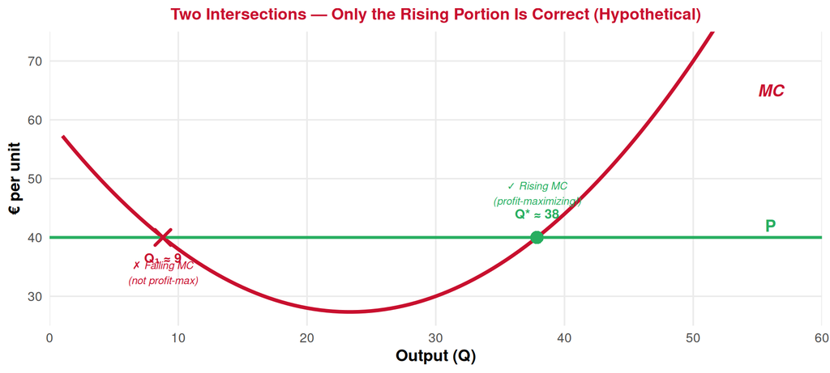

At Q₁ (falling MC): if you produce one more unit, MC is still falling — you can **increase** profit further! At Q* (rising MC): producing one more unit would cost **more** than the price. This is the true optimum.

## The Supply Rule: Formal Summary 📋

**The Complete Supply Rule for a Competitive Firm**

1. Find $Q^*$ where $P = MC$ on the **rising** portion of MC
2. If $P \geq AVC$ at $Q^*$ → **supply $Q^*$ units**
3. If $P < AVC$ at $Q^*$ → **supply 0 units** (shut down)

The individual supply curve is the **MC curve above AVC_min**.

**This rule answers three questions at once**:

| Question | Answer |
| --- | --- |
| **How much** to produce? | Where $P = MC$ (rising portion) |
| **Whether** to produce? | Only if $P \geq AVC$ |
| **How much profit?** | $\pi = (P - ATC) \times Q^*$ |

👉 One rule, three answers — that’s the power of marginal analysis!

# What Happens When Costs Change?

## The Textbook’s Key Insight: Changing the Price 📈

The textbook shows what happens when the bottle price **rises from €0.35 to €0.45**:

| Q (bottles/day) | MC per bottle | Profit at P=€0.35 | Profit at P=€0.45 |
| --- | --- | --- | --- |
| 0 | — | −40 | −40 |
| 100 | 0.10 | −15 | −5 |
| 200 | 0.10 | 10 | 30 |
| 300 | 0.20 | 25 | 55 |
| **400** | **0.30** | **30** | 70 |
| **500** | **0.40** | 25 | **75** |
| 600 | 0.50 | 10 | 70 |
| 700 | 0.60 | −15 | 55 |

*Source: Course textbook (sebenta), Tables 10 & 11*

- At P = €0.35: **Q* = 400** (MC ≈ 0.30, next batch MC = 0.40 > P)
- At P = €0.45: **Q* = 500** (MC ≈ 0.40, next batch MC = 0.50 > P)

👉 **Higher price → produce more → earn more profit**. The firm moves **up along its MC/supply curve**.

## The Textbook’s Key Insight: Changing Wages 💰

What if wages rise from €10/hour to **€12/hour** (keeping P = €0.35)?

| Q | LC at €10/hr | LC at €12/hr | TC (w=10) | TC (w=12) | Profit (w=10) | Profit (w=12) |
| --- | --- | --- | --- | --- | --- | --- |
| 0 | 0 | 0 | 40 | 40 | −40 | −40 |
| 100 | 10 | 12 | 50 | 52 | −15 | −17 |
| 200 | 20 | 24 | 60 | 64 | 10 | 6 |
| **300** | 40 | 48 | 80 | 88 | 25 | **17** |
| **400** | 70 | 84 | 110 | 124 | **30** | 16 |
| 500 | 110 | 132 | 150 | 172 | 25 | 3 |

*Source: Course textbook (sebenta), Tables 10 & 12*

- At w = €10/hr: **Q* = 400**, max profit = €30
- At w = €12/hr: **Q* = 300**, max profit = €17

👉 **Higher wages → MC rises at every Q → firm produces less at the same price**. The supply curve has **shifted left**!

## Visualizing a Supply Shift 🔄

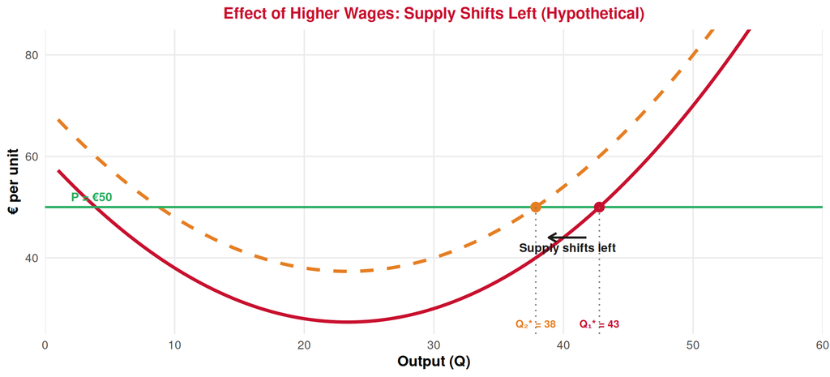

## Does Changing Fixed Costs Shift Supply? 🔒

The textbook also shows: when **FC rises from €40 to €70** (price stays at €0.35):

- **Q* stays at 400!** The profit-maximizing quantity doesn’t change.
- Profit drops from €30 to €0, but the **production decision** is unchanged.

. . .

**Fixed Costs Do Not Shift the Supply Curve in the Short Run**

MC depends only on **variable costs**. Since FC doesn’t affect MC, it doesn’t change the $P = MC$ intersection, and the supply curve stays in the same position.

FC affects **profit** (and the shutdown/exit decision in the long run), but not the **quantity supplied** at each price.

👉 **Movement along** the supply curve: caused by a change in the product’s **own price**

👉 **Shift of** the supply curve: caused by a change in **input prices** (wages, materials), **technology**, or **number of firms**

# Supply Curve Shifters

## What Shifts the Supply Curve? 🔄

**Shift RIGHT** (increase in supply) ➡️

More is supplied at every price when:

- 📉 **Input prices fall** (cheaper labor, fuel, materials)
- ⚙️ **Technology improves** (online booking systems, automation)
- 🌡️ **Favorable conditions** (good weather for agriculture, tourism)
- ➕ **More firms enter** the market
- 🏛️ **Government subsidies** or reduced regulation

*Tourism*: New low-cost airline tech → cheaper flights → supply of flights shifts right

**Shift LEFT** (decrease in supply) ⬅️

Less is supplied at every price when:

- 📈 **Input prices rise** (higher wages, energy costs)
- 🚫 **Regulation increases** (stricter licensing, environmental rules)
- ⚠️ **Adverse events** (natural disaster, pandemic)
- ➖ **Firms exit** the market
- 🧾 **Higher taxes** on producers

*Tourism*: New tourist tax → higher costs for hotels → supply shifts left

## Movement Along vs Shift: Supply Edition 🔍

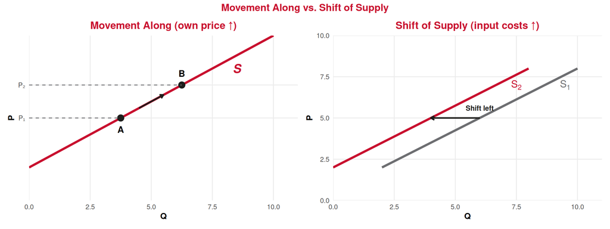

**Left**: When the product’s own price rises, the firm moves **along** its supply curve → $Q$ increases.

**Right**: When input costs rise (wages, energy), the entire supply curve **shifts left** → less supplied at every price.

💡 Exactly the same logic as demand (Lecture 8): own-price = movement along; other factors = shift!

# Tourism Applications

## Supply Shifts in Portuguese Tourism 🇵🇹

**Example 1: Minimum wage increase** 💰

Portugal’s minimum wage has been rising. For tourism businesses:

- Labor is a major variable cost (housekeeping, waitstaff, guides)
- Higher wages → MC shifts up → supply shifts **left**
- At the same hotel room price, fewer rooms are profitably offered
- Some marginal businesses may shut down ($P < AVC$ at new costs)

**Effect**: fewer beds at every price level, or higher prices to compensate

**Example 2: Online booking technology** 💻

Platforms like Booking.com, Airbnb:

- Reduce distribution costs (no need for travel agents)
- Lower marketing costs per booking
- MC shifts **down** → supply shifts **right**
- More accommodation available at every price point

**Effect**: more rooms at every price level — which has been the trend!

. . .

👉 Both examples change **variable costs**, which shifts MC and therefore the supply curve.

## Supply Shifts: Seasonal Staffing in the Algarve ☀️

**Why is the supply of tourism services different in summer vs winter?**

The $P = MC$ rule explains it:

☀️ **Summer**:

- Abundant seasonal workers → wages moderate
- MC is **relatively low** for extra services
- Supply curve is **further right**
- More tours, restaurants, activities offered

❄️ **Winter**:

- Workers move to other sectors → must pay more to retain
- Energy costs higher (heating)
- MC is **higher** for the same services
- Supply curve shifts **left**
- Fewer services offered

. . .

💡 **Combined with demand shifts**: In summer, both supply and demand are higher. In winter, both shift left. The net effect on price depends on which shift is larger — this is **market equilibrium** (Lecture 17)!

## The Parallel with Demand 🤝

Throughout the course, we’ve built **mirror-image** tools for consumers and producers:

| Concept | Consumer (Demand) | Producer (Supply) |
| --- | --- | --- |
| **Goal** | Maximize utility | Maximize profit |
| **Constraint** | Budget ($M$) | Cost structure ($TC$) |
| **Individual curve** | From utility maximization | From $P = MC$ (above AVC) |
| **Curve shape** | Downward-sloping 📉 | Upward-sloping 📈 |
| **Movement along** | Own price changes | Own price changes |
| **Shift** | Income, preferences, other prices | Input costs, technology, # firms |
| **Surplus** | Consumer surplus (area below D, above P) | Producer surplus (next lecture!) |
| **Market curve** | Horizontal sum of individual D | Horizontal sum of individual S |

## Summary 📝

**Today’s Key Takeaways**:

1. **The seller’s supply rule**: Produce where $P = MC$ on the rising portion of MC, provided $P \geq AVC$
2. This follows directly from the **cost-benefit principle** — produce as long as $P \geq MC$
3. The rule answers three questions: **how much**, **whether**, and **how profitable**
4. **Higher product price** → movement **along** the supply curve (more produced)
5. **Higher input costs** (wages, energy) → MC shifts up → supply curve shifts **left**
6. **Better technology** → MC shifts down → supply curve shifts **right**
7. **Fixed costs don’t shift supply** in the short run (they don’t affect MC)
8. Supply and demand are **mirror images** — built from the same marginal analysis logic

**Connection**: We now have the individual firm’s supply curve. Next lecture: **producer surplus** and how to build the **market supply** from individual firms.

**Next (Lecture 14, April 9)**: Producer Surplus, Market Supply, and Linear Supply 📈

## Exercises

**Practice Time!** ✏️

The supply rule, cost changes, and supply shifts.

## Exercise 1: Multiple Choice

**Question**: A sardine restaurant in Lisbon operates in a competitive market. Currently, $P = €12$ per meal and $MC = €10$ at the restaurant’s current output level. The restaurant should:

A. Keep output the same — it is already maximizing profit

B. Increase output — producing more will add to profit

C. Decrease output — the restaurant is overproducing

D. Shut down — it is not covering costs

**Answer: B**

Since $P = €12 > MC = €10$, each additional meal earns €12 in revenue but costs only €10. The restaurant should **expand output** until MC rises to meet $P = €12$. At the current output, there is still “room” to increase profit by producing more.

Only when $P = MC$ should the firm stop expanding.

## Exercise 2: Multiple Choice

**Question**: The Portuguese government introduces a new tourist tax of €2 per hotel night, paid by the hotel. Which of the following is correct?

A. The hotel’s supply curve shifts right by €2

B. The hotel’s supply curve shifts left (up by €2) — at each price, less is supplied

C. The hotel moves along its existing supply curve

D. The hotel’s demand curve shifts left

**Answer: B**

The tax increases the **variable cost** of each room-night by €2. This shifts MC **up** by €2 at every output level, which means the supply curve shifts **left** (equivalently, upward by €2).

At any given market price, the hotel now produces **less** because $P = MC$ is reached at a lower quantity. This is a **shift** of supply, not a movement along it (C is wrong), because the change is in costs, not the product’s own price. And it’s the supply curve, not demand (D is wrong).

## Exercise 3: Open Question ✍️

**A small boat tour company in Cascais** faces the following situation. The market price for a coastal tour is **€40 per ticket**. The firm’s cost structure is:

| Tours/day (Q) | FC (€) | VC (€) | TC (€) | MC (€/tour) |
| --- | --- | --- | --- | --- |
| 0 | 300 | 0 | 300 | — |
| 1 | 300 | 15 | 315 | 15 |
| 2 | 300 | 28 | 328 | 13 |
| 3 | 300 | 39 | 339 | 11 |
| 4 | 300 | 52 | 352 | 13 |
| 5 | 300 | 70 | 370 | 18 |
| 6 | 300 | 96 | 396 | 26 |
| 7 | 300 | 133 | 433 | 37 |
| 8 | 300 | 184 | 484 | 51 |

*Hypothetical illustrative example*

**a)** Using the $P = MC$ rule, what is the profit-maximizing output at $P = €40$? Calculate profit.

**b)** Now fuel costs rise, adding €10 to the MC of each tour. Write the new MC column. What is the new profit-maximizing output? Calculate the new profit.

**c)** Has the supply curve shifted or has the firm moved along it? Explain.

**d)** At the original cost structure, what is the lowest price at which this firm would still produce? (What is the shutdown price?)

**e)** Draw (describe) what the firm’s supply curve looks like: at what price does it “start,” and what does it follow?

## Exercise 3: Solution — Part a

**a)** Apply $P = MC$ on the rising portion:

| Q | MC | P vs MC |
| --- | --- | --- |
| 3 | 11 | P = 40 > MC → produce |
| 4 | 13 | P = 40 > MC → produce |
| 5 | 18 | P = 40 > MC → produce |
| 6 | 26 | P = 40 > MC → produce |
| 7 | 37 | P = 40 > MC → produce |
| 8 | 51 | P = 40 < MC → **stop!** |

**Q* = 7 tours/day** (last tour where $P \geq MC$).

Profit: $\pi = TR - TC = (40 \times 7) - 433 = 280 - 433 = -€153$

The firm makes a **loss** of €153/day. But should it still operate? AVC at Q = 7: $\frac{133}{7} = €19$. Since $P = €40 > AVC = €19$: **yes, operate!** Shutdown loss would be −€300 (= FC), which is worse.

## Exercise 3: Solution — Parts b & c

**b)** New MC = old MC + €10:

| Q | Old MC | New MC | P = 40 vs New MC |
| --- | --- | --- | --- |
| 1 | 15 | 25 | 40 > 25 → produce |
| 2 | 13 | 23 | 40 > 23 → produce |
| 3 | 11 | 21 | 40 > 21 → produce |
| 4 | 13 | 23 | 40 > 23 → produce |
| 5 | 18 | 28 | 40 > 28 → produce |
| 6 | 26 | 36 | 40 > 36 → produce |
| 7 | 37 | **47** | 40 < 47 → **stop!** |

**New Q* = 6 tours/day** (down from 7).

New VC at Q = 6: old VC + 6 × €10 = €96 + €60 = €156. New TC = 300 + 156 = €456.

New profit: $\pi = (40 \times 6) - 456 = 240 - 456 = -€216$ (loss worsened from −€153 to −€216).

**c)** This is a **shift of the supply curve**, not a movement along it. The price didn’t change (still €40) — what changed was the **input cost** (fuel). Higher variable costs shift MC upward, which shifts the supply curve **left**. At the same price, the firm now supplies fewer tours (6 instead of 7).

## Exercise 3: Solution — Parts d & e

**d)** The shutdown price = $AVC_{\min}$.

Calculate AVC at each Q:

| Q | VC | AVC = VC/Q |
| --- | --- | --- |
| 1 | 15 | 15.00 |
| 2 | 28 | 14.00 |
| 3 | 39 | 13.00 |
| 4 | 52 | **13.00** |
| 5 | 70 | 14.00 |
| 6 | 96 | 16.00 |

**Shutdown price** = $AVC_{\min}$ = **€13** (at Q = 3–4). Below €13, the firm should produce nothing.

**e)** The firm’s supply curve:

- For $P < €13$: **Q = 0** (shut down)
- For $P \geq €13$: follow the **MC curve on its rising portion** (starting around Q = 3–4)
- As P rises, Q* increases: e.g., P = 18 → Q = 5, P = 26 → Q = 6, P = 37 → Q = 7, etc.

The supply curve **starts at the shutdown point** (P = €13, Q ≈ 3–4) and follows MC upward.

## Next Lecture

**April 9, 2026**: Producer Surplus, Market Supply, and Linear Supply 📈

We’ll introduce **producer surplus** (the supply-side mirror of consumer surplus), build **market supply** from individual firms, and work with **linear supply equations**.

## Thank You!

**Questions?** 🙋

📧 paulo.fagandini@ext.universidadeeuropeia.pt

*Next class: Wednesday, April 9, 2026*